# Modifications to sicegar: Analysis of Single-Cell Viral Growth Curves

10 November 2025

# Summary

The R package **sicegar** aims to quantify time-intensity data by using sigmoidal and double-sigmoidal curves. The method was originally developed in the context of single-cell viral growth analysis (for details, see Caglar, Teufel, and Wilke (2018)), and the package name stands for “SIngle CEll Growth Analysis in R”. In addition to categorizing the best model fit, **sicegar** returns parameter estimates for each of the model fits, providing important information to researchers.

The sigmoidal function is given as $I(x)$, with parameters estimated using the Levenberg-Marquardt algorithm (Levenberg 1944; Marquardt 1963). $h_0$ represents the lower asymptote (as $x$ approaches negative infinity). $t_1$ is the onset time (the inflection point) and the midpoint between $h_0$ and $h_1$. $a$ determines the magnitude of the slope of the sigmoidal curve. $h_1$ is the upper asymptote (as $x$ approaches positive infinity). The parameters describing the sigmoidal curve in $I(x)$ are graphically represented in **Figure 1**.

$I(x) = h_0 + \frac{h_1-h_0}{1 + e^{-a(x - t_1)}}$

A similar, but slightly more complicated, formula for the double-sigmoidal function is also used for parameter estimation in **sicegar**. In the original implementation of **sicegar**, the parameter $h_0$ is set to zero for both the sigmoidal and double-sigmoidal models.

**Figure 1** Visualization of the sigmoidal curve and related parameter values.

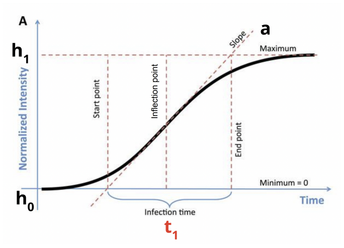

Sigmoidal curve.

**sicegar**’s parameter estimation allows users to extract key model parameters, including the onset time of RNA expression in specific genes (Caglar, Teufel, and Wilke 2018). Onset time is defined as the time when the half-maximal abundance of RNA is reached in the cell. For example, Adams et al. (2023) uses **sicegar** to investigate the onset time of RNA expression from genes in *E. coli* undergoing stress. Accurate estimates of $t_1$ are crucial for understanding transcriptional timing of genes. However, Adams et al. (2023) observed limitations in **sicegar**’s fits, which motivated the package improvements proposed in our paper.

We have substantially modified **sicegar** (our work is currently implemented on CRAN) to improve the parameter estimates for both sigmoidal and double-sigmoidal models. Our primary update to the **sicegar** package is the inclusion and estimation of an additional parameter, $h_0$, the lower asymptote of both the sigmoidal and double-sigmoidal curves, which had previously been set equal to zero. Based on simulated data, the free estimation of $h_0$ provides both a better overall model fit (lower SSE) and more accurate parameter estimates than when $h_0$ is forced to be equal to zero.

# Statement of Need

Caglar, Teufel, and Wilke (2018) discuss **sicegar**’s ability to correctly identify sigmoidal and double-sigmoidal curves on simulated data. They report, “Overall, we can conclude that our algorithm results in reliable fits, that it fails gradually with increasing noise levels, and that it is conservative in assessing whether it has correctly identified a sigmoidal or double-sigmoidal curve or not.” The focus of their results is on whether **sicegar** is able to correctly identify sigmoidal and double-sigmoidal curves on simulated data, not on whether it is able to accurately estimate parameters. Although they acknowledge **sicegar**’s ability to estimate parameters associated with sigmoidal and double-sigmoidal curves, they do not report on the accuracy of the parameter estimates.

# Research Impact Statement

**sicegar** has been a useful tool which has had substantial research impact since its initial release. The original paper (Caglar, Teufel, and Wilke 2018) on **sicegar** has been cited more than 50 times (Google Scholar, January 2026). The flexibility of the sigmoidal and double-sigmoidal models make the model fitting applicable to many different types of data and systems. The publications which cite **sicegar** range from molecular biology (Anderson and Hand 2021) to linguistics (Pouplier et al. 2024) to ecology (Ferrenberg et al. 2023). As detailed above, many of the publications go beyond the original intent of the package (does the model fit?) to needs for specific parameter estimates (our update to the package). **sicegar** has been downloaded from CRAN 35,957 times (as of January 2026).

# State of the Field

Base R comes standard with an excellent non-linear least squares solver, `nls()` which uses Gauss-Newton optimization. `nls()` is good when it works, but often fails (Nash 2014); **sicegar** use the Levenberg–Marquardt algorithm which alternates between Gauss-Newton and gradient descent. Software exists to model logistic curves (similar to single sigmoidal curves) but not double-sigmoidal curves (e.g., **drc** (C. Ritz et al. 2015), **qpcR** (Christian Ritz and Spiess 2008), **nplr** (Commo, Bot, and Kwiecinski 2025)) Other R packages that specifically support both sigmoidal and double-sigmoidal models are no longer supported in recent versions of R; for example, consider **grofit** (Kahm et al. 2010) and **ImpulseDE2** (Chechik and Koller 2009). **sicegar** models both sigmoidal and double-sigmoidal curves reliably. We have contributed to the **sicegar** package by extending the parameter space and focusing on parameter estimation, tasks that none of the existing software programs implement.

# Software Design

`fitAndCategorize`, the umbrella function in **sicegar**, takes time-intensity data as an argument and runs the data through a series of nested functions. The process is outlined in **Figure 2**. First, the data are normalized in the function `normalizeData` (1). Then they are passed through `multipleFitFunction` (2) which uses the Levenberg-Marquardt algorithm (Levenberg 1944; Marquardt 1963) to fit both sigmoidal and double-sigmoidal curves to the data, (3), (4). Additional parameters are estimated using `parameterCalculations`, and the model is visualized using `figureModelCurves`. The user decides whether to allow the function to estimate $h_0$ using the argument `use_h0 = TRUE` in `fitAndCategorize`. If `use_h0` is set to `FALSE` (the default, for backward compatibility), the algorithm will run **sicegar** using the original implementation, with $h_0$ fixed at zero. If the user chooses to estimate $h_0$, the same function flow is followed, and each sub-function will account for the estimate of $h_0$.

### Novel Contributions

Each function in **sicegar** was rewritten to include the parameter $h_0$. Our new version is outlined in the right-hand branch of **Figure 2**.

**Figure 2** Structure of the `fitAndCategorize` function.

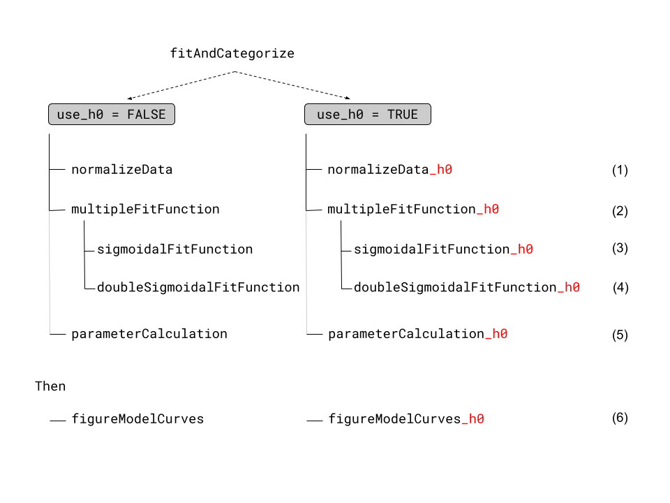

Structure of the `fitAndCategorize` function.

### Example

**Figure 3** Parameter estimates from simulated data.

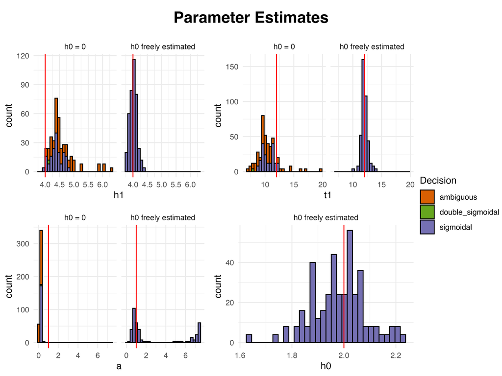

Parameter estimates from simulated data.

# Availability

The **sicegar** package is available on CRAN (https://CRAN.R-project.org/package=sicegar) and GitHub (https://github.com/hardin47/sicegar). Documentation, including vignettes and examples, is provided to facilitate adoption.

# AI usage disclosure

# Acknowledgements

The authors gratefully acknowledge Dan Stoebel for bringing the application to our attention and Federica Domecq Lacroze for sharing her explorations of the **sicegar** package. PC, TM, and MT were supported by the Pomona College SURP program, and SB was supported by the Kenneth Cooke Summer Research Fellowship. JH was supported in part by NIH GM112625.

# References

Adams, Josephine, Johnson Hoang, Emily Petroni, Ethan Ashby, Johanna Hardin, and Daniel M. Stoebel. 2023. “The Timing of Transcription of *rpoS*-Dependent Genes Varies Across Multiple Stresses in *Escherichia Coli* k-12.” *mSystems* 8 (5): e00663–23. https://doi.org/10.1128/msystems.00663-23.

Anderson, John M., and Steven C. Hand. 2021. “Transgenic Expression of Late Embryogenesis Abundant Proteins Improves Tolerance to Water Stress in Drosophila Melanogaster.” *Journal of Experimental Biology* 224 (4): jeb238204. https://doi.org/10.1242/jeb.238204.

Caglar, M. Umut, Ashley I. Teufel, and Claus O. Wilke. 2018. “Sicegar: R Package for Sigmoidal and Double-Sigmoidal Curve Fitting.” *PeerJ* 6: e4251. https://doi.org/10.7717/peerj.4251.

Chechik, Gal, and Daphne Koller. 2009. “Timing of Gene Expression Responses to Environmental Changes.” *Journal of Computational Biology* 16 (2): 279–90. https://doi.org/10.1089/cmb.2008.13TT.

Commo, Frederic, Brian M. Bot, and Tymoteusz Kwiecinski. 2025. *Nplr: N-Parameter Logistic Regression*. https://CRAN.R-project.org/package=nplr.

Ferrenberg, Scott, Carla Vázquez-González, Steven R. Lee, and Milda Kristupaitis. 2023. “Divergent Growth-Differentiation Balance Strategies and Resource Competition Shape Mortality Patterns in Ponderosa Pine.” *Ecosphere* 14 (1): e4349. https://doi.org/https://doi.org/10.1002/ecs2.4349.

Kahm, Matthias, Guido Hasenbrink, Hella Lichtenberg-Fraté, Jost Ludwig, and Maik Kschischo. 2010. “grofit: Fitting Biological Growth Curves with R.” *Journal of Statistical Software* 33 (7): 1–21. https://doi.org/10.18637/jss.v033.i07.

Levenberg, Kenneth. 1944. “A Method for the Solution of Certain Non-Linear Problems in Least Squares.” *Quarterly of Applied Mathematics* 2 (2): 164–68. https://doi.org/10.1090/qam/10666.

Marquardt, Donald W. 1963. “An Algorithm for Least-Squares Estimation of Non-Linear Parameters.” *SIAM Journal on Applied Mathematics* 11 (2): 431–41.

Nash, John C. 2014. “On Best Practice Optimization Methods in R.” *Journal of Statistical Software* 60 (2): 1–14. https://doi.org/10.18637/jss.v060.i02.

Pouplier, Marianne, Francesco Rodriquez, Justin J. H. Lo, Roy Alderton, Bronwen G. Evans, Eva Reinisch, and Christopher Carignan. 2024. “Language-Specific and Individual Variation in Anticipatory Nasal Coarticulation: A Comparative Study of American English, French, and German.” *Journal of Phonetics* 107: 101365. https://doi.org/https://doi.org/10.1016/j.wocn.2024.101365.

Rajarathinam, Yogeswari, Luisa Wittemeier, Kirstin Gutekunst, Martin Hagemann, and Joachim Kopka. 2025. “Dynamic Photosynthetic Labeling and Carbon-Positional Mass Spectrometry Monitor in Vivo RUBISCO Carbon Assimilation Rates.” *Plant Physiology* 197 (2): kiaf020. https://doi.org/10.1093/plphys/kiaf020.

Ritz, C., F. Baty, J. C. Streibig, and Gerhard D. 2015. “Dose-Response Analysis Using R.” *PLoS ONE* 10 (12): e0146021. https://doi.org/10.1371/journal.pone.0146021.

Ritz, Christian, and Andrej-Nikolai Spiess. 2008. “qpcR: An r Package for Sigmoidal Model Selection in Quantitative Real-Time Polymerase Chain Reaction Analysis.” *Bioinformatics* 24 (13): 1549–51. https://doi.org/10.1093/bioinformatics/btn227.

Wittemeier, Luisa, Yogeswari Rajarathinam, Alexander Erban, Martin Hagemann, and Joachim Kopka. 2025. “Positional 13C Enrichment Analysis of Aspartate Determines PEPC Activity in Vivo.” *New Phytologist*.